# Probability Distribution

Taewook Lee

# 1 R의 기초 사용법 (본 강의에 필요한 내용을 위주로 간략히)

## 1.1 백터와 행렬

> 벡터의 생성 함수 c()는 괄호안에 있는 숫자 혹은 문자를 순서대로 벡터로 묶는 (concatenation) 역할을 한다.

> 기본적인 산술 연산에는 “+” , “-”, “*“,”/" ,“^”을 이용해 각 성분 별로 연산 할 수 있다

```r
x = c(1,2,3) ; y = c(4,5,6)
z = c(x, y, 7)
z
```

```
## [1] 1 2 3 4 5 6 7
```

```r
x+y
```

```
## [1] 5 7 9
```

```r
x-y
```

```
## [1] -3 -3 -3
```

```r
x*y
```

```
## [1]  4 10 18
```

```r
x/y
```

```
## [1] 0.25 0.40 0.50
```

```r
x^y
```

```
## [1]   1  32 729
```

> 길이가 서로 다른 벡터간 산술 연산을 하면 계산 결과는 길이가 더 긴 것과 같은 벡터가 된다.

> 짧은 벡터는 긴벡터의 길이가 부족한 만큼 반복해서 연산 된다.

```r
x = c(1,2,3,4,5,6) ; y = c(1,2,3)
x+y
```

```
## [1] 2 4 6 5 7 9
```

```r
x*y
```

```
## [1]  1  4  9  4 10 18
```

```r
x-y
```

```
## [1] 0 0 0 3 3 3
```

```r
x^y
```

```
## [1]   1   4  27   4  25 216
```

```r
x/y
```

```
## [1] 1.0 1.0 1.0 4.0 2.5 2.0
```

> 행렬(matrix)는 2차원 인덱스를 사용하는 배열의 특별한 경우에 대항한다. 함수 array() 이용한다.

> matrix(data, nrow, ncol)

```r
z <- matrix(1:20, nrow=4,ncol= 5)
z
```

```
##      [,1] [,2] [,3] [,4] [,5]
## [1,]    1    5    9   13   17
## [2,]    2    6   10   14   18
## [3,]    3    7   11   15   19
## [4,]    4    8   12   16   20
```

> index 하기

```r
z[2,3]
```

```
## [1] 10
```

```r
z[1:3,]
```

```
##      [,1] [,2] [,3] [,4] [,5]
## [1,]    1    5    9   13   17
## [2,]    2    6   10   14   18
## [3,]    3    7   11   15   19
```

```r
z[c(1,3),]
```

```
##      [,1] [,2] [,3] [,4] [,5]
## [1,]    1    5    9   13   17
## [2,]    3    7   11   15   19
```

> matrix 연산 t(): transpose , “+”,“-”,“/”,“^”,“%*%"

```r
# 2번째 행과 3번째 열의 값
a= matrix(2,3,2)
b= matrix(3,3,2)
c= matrix(2,2,2)
d= matrix(2,3,1)
t(a)
```

```
##      [,1] [,2] [,3]
## [1,]    2    2    2
## [2,]    2    2    2
```

```r
a+b
```

```
##      [,1] [,2]
## [1,]    5    5
## [2,]    5    5
## [3,]    5    5
```

```r
a-b # 행과 열의 사이즈가 동일해야 가능
```

```
##      [,1] [,2]
## [1,]   -1   -1
## [2,]   -1   -1
## [3,]   -1   -1
```

```r
a/b
```

```
##           [,1]      [,2]
## [1,] 0.6666667 0.6666667
## [2,] 0.6666667 0.6666667
## [3,] 0.6666667 0.6666667
```

```r
a^b
```

```
##      [,1] [,2]
## [1,]    8    8
## [2,]    8    8
## [3,]    8    8
```

```r
a*b # 크기가 같은 두 행렬사이에서 사용되면, 두 행렬의 각 성분끼리 곱셈을 한 행렬을 만든다.
```

```
##      [,1] [,2]
## [1,]    6    6
## [2,]    6    6
## [3,]    6    6
```

```r
a%*%c # 행렬곱셈(matrix multiplication) 을 원 할 때는 반드시 %*% 사용한다. 3 x 2 %*% 2 x 2 = 3 x 2
```

```
##      [,1] [,2]
## [1,]    8    8
## [2,]    8    8
## [3,]    8    8
```

## 1.2 등차수열의 생성

> 등차수열을 생성하는 함수 seq()는 여러모로 유용한 함수이다. 예를 들어 0부터 시작해서 0.01씩 증가해서 1로 끝나는 수열을 얻고 싶으면 다음과 같이 입력하면 된다.

```r
x = seq(from=0,to=1,by=0.01)
x
```

```
##   [1] 0.00 0.01 0.02 0.03 0.04 0.05 0.06 0.07 0.08 0.09 0.10 0.11 0.12 0.13
##  [15] 0.14 0.15 0.16 0.17 0.18 0.19 0.20 0.21 0.22 0.23 0.24 0.25 0.26 0.27
##  [29] 0.28 0.29 0.30 0.31 0.32 0.33 0.34 0.35 0.36 0.37 0.38 0.39 0.40 0.41
##  [43] 0.42 0.43 0.44 0.45 0.46 0.47 0.48 0.49 0.50 0.51 0.52 0.53 0.54 0.55
##  [57] 0.56 0.57 0.58 0.59 0.60 0.61 0.62 0.63 0.64 0.65 0.66 0.67 0.68 0.69
##  [71] 0.70 0.71 0.72 0.73 0.74 0.75 0.76 0.77 0.78 0.79 0.80 0.81 0.82 0.83
##  [85] 0.84 0.85 0.86 0.87 0.88 0.89 0.90 0.91 0.92 0.93 0.94 0.95 0.96 0.97
##  [99] 0.98 0.99 1.00
```

> 증분이 1이고 정수로 이루어진 수열, 예를 들어 2부터 5까지의 자연수로 이루어진 벡터를 출력하여 보고 싶으면 간단히 다음과 같이 입력하면 된다.

```r
x = 2:5
x
```

```
## [1] 2 3 4 5
```

## 1.3 조건문: if 문

> if 문을 사용해 조건문을 만드는 방법은 다음과 같다: if (condition) expr_1 else expr_2

> else 이후의 문장은 생략할 수 있다.

```r
x = 1:4
if ( sum(x) > 12) {y=1;z=0} else {y=2;z=1}
y
```

```
## [1] 2
```

```r
z
```

```
## [1] 1
```

## 1.4 루프: for 문

> for 문을 사용해 루프을 만드는 방법은 다음과 같다: for ( name in expr_1) expr_2

> name은 루프 변수의 이름이고, expr_1은 벡터(보통은 1:20과 같은 수열), expr_2은 그룹화된 문장이다.

```r
s=0; p=1
for (i in 1:10) {

  s = s+i
  p = p*i

}

s
```

```
## [1] 55
```

```r
p
```

```
## [1] 3628800
```

## 1.5 새로운 함수의 정의

> R에서 기본적으로 제공되는 함수들 외에 사용자의 필요에 의해 새로운 함수를 정의하여 사용하는 것이 가능하다.

> 함수를 정의하는 방법은 다음과 같다: name = function(arg_1,arg_2,….) expr

> 새롭게 정의된 함수가 되돌려주는 값은 expr 부분에 return()을 이용하여 정의한다.

> expr 부분에서 새롭게 정의된 변수나 객체는 그 함수의 정의 내에서만 유효한 국소적 성질을 갖는다.

```r
fcn = function(x,y) {

  ans = sqrt(x^2+y^2)
  return(ans)

}

fcn(3,4)
```

```
## [1] 5
```

### 1.5.1 Quiz 1

> function과 for문을 이용해 $1^2 + 2^3 + 3^4 + 4^5 + 5^6$ 를 구해라

```r
d= 0

f <- function(x) {
  for (i in 1:x) {
    d= d + i^(i+1)
  }
  return(d)
}
f(5)
```

```
## [1] 16739
```

## 1.6 plot() 함수

> 이차원 그래프를 그리는 데에 가장 자주 쓰이는 함수가 plot() 이다. 다음은 plot()으로 그린 sine, cosine 곡선이다.

```r
x = seq(from=0,to=2*pi, by=0.01)
y = sin(x); z = cos(x)
head(x);head(y);head(z)
```

```
## [1] 0.00 0.01 0.02 0.03 0.04 0.05
```

```
## [1] 0.000000000 0.009999833 0.019998667 0.029995500 0.039989334 0.049979169
```

```
## [1] 1.0000000 0.9999500 0.9998000 0.9995500 0.9992001 0.9987503
```

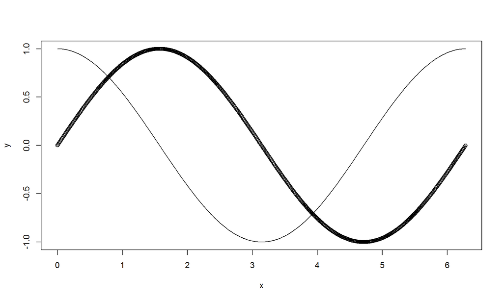

```r
plot(x,y)
lines(x,z)
```

## 1.7 persp() contour() 함수 install.packages(“mtvnorm”)

> 이차원 정규분포 등고선 모형과 3d 모형으로 출력하기

```r
library(mvtnorm)
# x=0, y=0 에 대해 x , y 평균은 0 covariance matrix 2x2 크기의 단위행렬
dmvnorm(c(0,0), mean= rep(0,2), sigma= diag(2))
```

```
## [1] 0.1591549
```

```r
x <- seq(-3,3,by =.1)
y <- x

dmvnorm(cbind(x,y), mean=rep(0,2), sigma = diag(2))
```

```
##  [1] 1.964128e-05 3.543264e-05 6.265437e-05 1.085959e-04 1.844971e-04
##  [6] 3.072413e-04 5.015150e-04 8.024211e-04 1.258447e-03 1.934557e-03
## [11] 2.915024e-03 4.305435e-03 6.233127e-03 8.845229e-03 1.230343e-02
## [16] 1.677481e-02 2.241831e-02 2.936719e-02 3.770822e-02 4.745957e-02
## [21] 5.854983e-02 7.080136e-02 8.392120e-02 9.750252e-02 1.110386e-01
## [26] 1.239500e-01 1.356229e-01 1.454567e-01 1.529144e-01 1.575713e-01
## [31] 1.591549e-01 1.575713e-01 1.529144e-01 1.454567e-01 1.356229e-01
## [36] 1.239500e-01 1.110386e-01 9.750252e-02 8.392120e-02 7.080136e-02
## [41] 5.854983e-02 4.745957e-02 3.770822e-02 2.936719e-02 2.241831e-02
## [46] 1.677481e-02 1.230343e-02 8.845229e-03 6.233127e-03 4.305435e-03
## [51] 2.915024e-03 1.934557e-03 1.258447e-03 8.024211e-04 5.015150e-04
## [56] 3.072413e-04 1.844971e-04 1.085959e-04 6.265437e-05 3.543264e-05
## [61] 1.964128e-05
```

```r
outer <- outer(x,y, function(x,y){dmvnorm(cbind(x,y), mean=rep(0,2), sigma = diag(2)) })
length(x); length(y) ; dim(outer)
```

```
## [1] 61
```

```
## [1] 61
```

```
## [1] 61 61
```

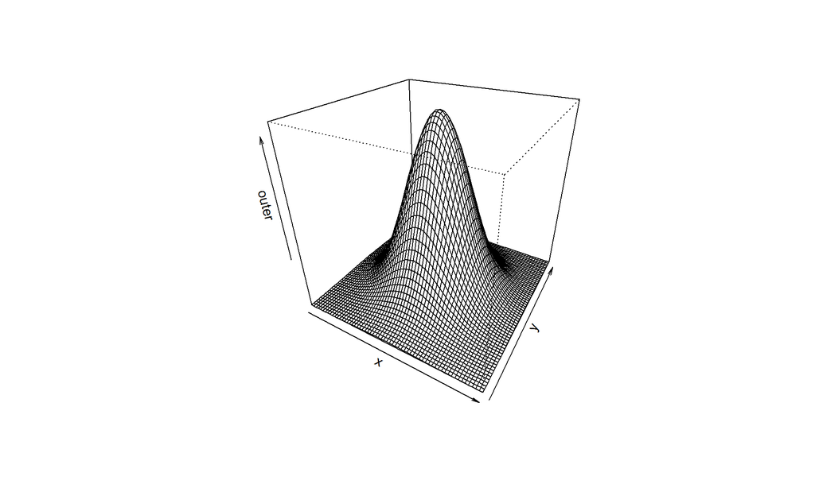

```r
persp(x, y, outer, theta=30, phi=30)
```

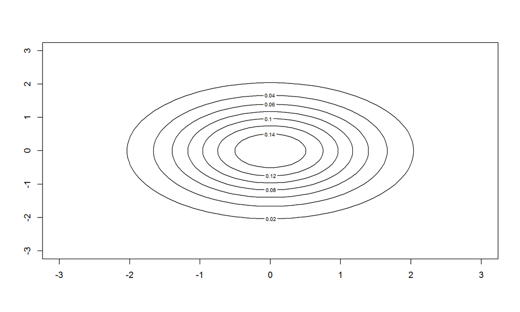

```r
contour(x,y,outer)
```

### 1.7.1 Quiz 2

> $f(x,y) = sin(x)^2 + cos(y)^2$ 에 대해서 persp 와 counter 해보기

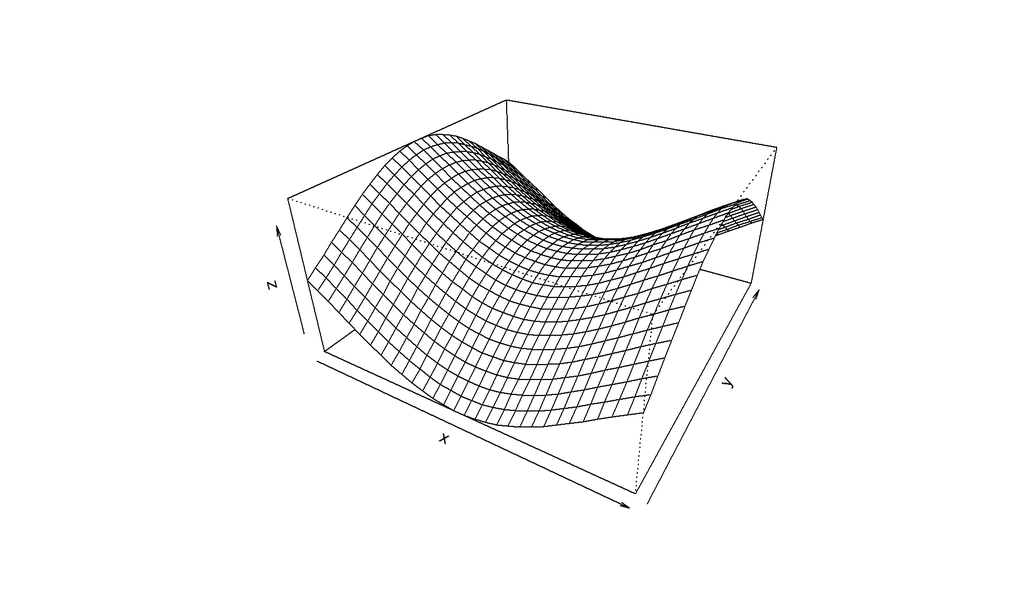

```r
x = seq(-1,1, length=30) ; y = x ;
f <- function(x,y){
  r <- sin(x)^2+cos(y)^2 ;
}
z = outer(x,y, f)
persp(x,y,z ,theta=30, phi=30, expand=0.5)
```

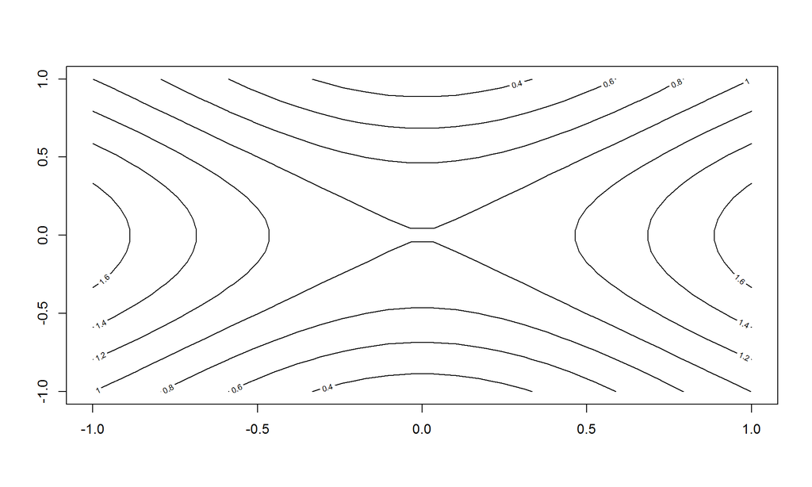

```r
contour(x,y,z)
```

# 2 Probability Distribution

## 2.1 Uniform distribution

> 아래 결과는 각각 U(0,1), U(-1,1), U(0,100)을 따르는 자료 10개를 생성한 것이다.

```r
runif(10,min=0,max=1.0)
```

```
##  [1] 0.88430569 0.55742453 0.58490532 0.06099718 0.84441090 0.41841705
##  [7] 0.56691734 0.96223984 0.06283575 0.86207949
```

```r
runif(10,min=-1.0,max=1.0)
```

```
##  [1]  0.11427660 -0.76330526  0.73994759 -0.65685741 -0.45698850
##  [6]  0.08025959 -0.37730571  0.22058352  0.81830176  0.61562830
```

```r
runif(10,min=0,max=100)
```

```
##  [1] 63.78396 55.55726 34.19836 38.55264 14.77922 35.03756 61.67115
##  [8] 35.70904 76.18819 10.45237
```

## 2.2 Binomial distribution

> 앞면이 나올 확률이 0.3인 구부러진 동전을 던지는 실험을 독립적으로 5번 반복 실시하였다. 총 시행 중 앞면이 나온 횟수를 $X$라 하자. 이 때, 확률분포를 그리고, 앞면이 3번 이상 나올 확률을 구하여라.

```r
n=5; p=0.3; x=0:n

px = dbinom(x,n,p) ## dbinom는 확률밀도함수(PDF)값 생성

x
```

```
## [1] 0 1 2 3 4 5
```

```r
px
```

```
## [1] 0.16807 0.36015 0.30870 0.13230 0.02835 0.00243
```

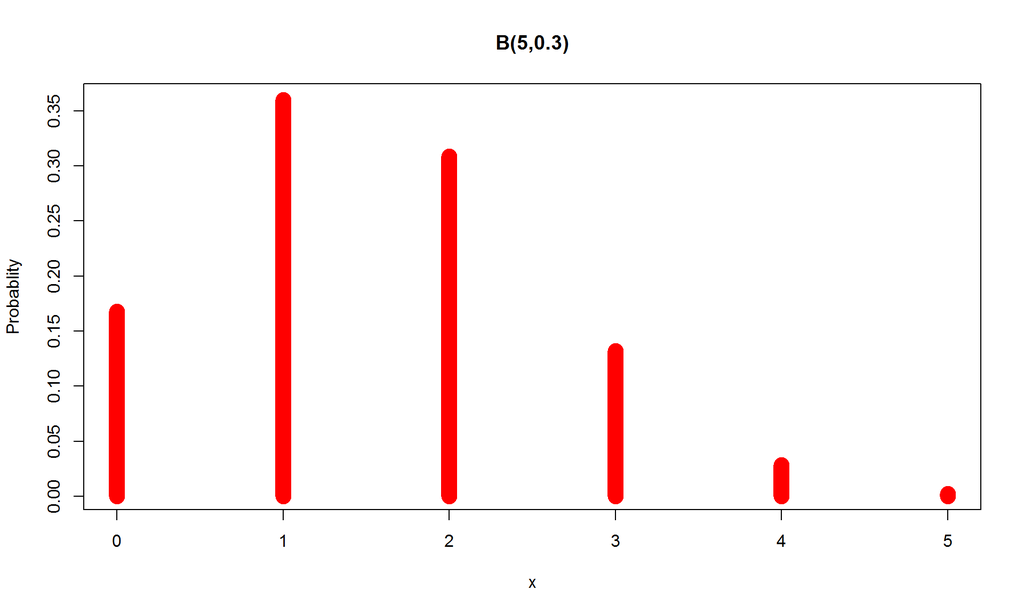

```r
plot(x, px, type="h", col="red", lwd=15, main="B(5,0.3)",xlab="x",ylab="Probablity")
```

```r
1 - pbinom(2,5,0.3)  ## pbinom는 누적분포함수(CDF)값 생성
```

```
## [1] 0.16308
```

> 아래 그림은 시행횟수 n=5이고 성공의 확률 p=0.3,0.5,0.7 일때 이항분포의 그림이다.

> 한 화면에 여러 개의 패널을 이용해 행렬처럼 나타내려면 par(mfrow=c(a,b))를 이용하면 된다. 여기서, a는 행의 수, b는 열의 수를 나타낸다. 예를 들어 par(mfrow=c(1,3))이면 1$\times$ 3 행렬의 형태로 그림을 그린다.

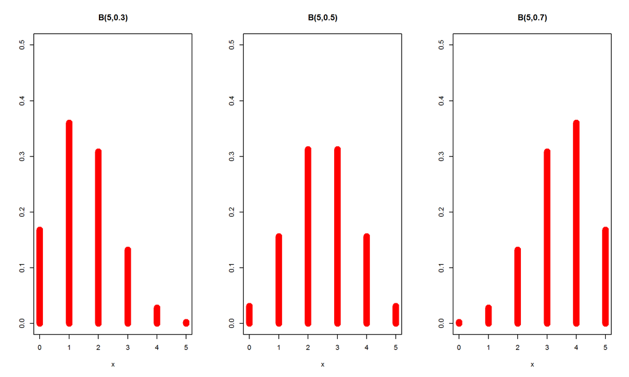

```r
n=5; x=0:n

par(mfrow=c(1,3))
plot(x,dbinom(x,n,0.3),type="h",col="red",lwd=10,main="B(5,0.3)",xlab="x",ylab="",ylim=c(0,0.5))
plot(x,dbinom(x,n,0.5),type="h",col="red",lwd=10,main="B(5,0.5)",xlab="x",ylab="",ylim=c(0,0.5))
plot(x,dbinom(x,n,0.7),type="h",col="red",lwd=10,main="B(5,0.7)",xlab="x",ylab="",ylim=c(0,0.5))
```

> 아래 결과는 시행횟수 n=10이고 성공의 확률 p=0.3,0.5,0.7인 이항분포를 따르는 자료 10개를 생성한 것이다.

```r
n=10

rbinom(10,size=n,prob=0.3)
```

```
##  [1] 1 3 4 3 3 3 4 2 1 0
```

```r
rbinom(10,size=n,prob=0.5)
```

```
##  [1] 4 3 4 2 3 8 7 4 4 5
```

```r
rbinom(10,size=n,prob=0.7)
```

```
##  [1] 8 4 8 6 6 8 8 7 6 8
```

## 2.3 Poisson distribution

> 평균이 0.5인 포아송 확률변수 $X$에 대하여 $P(X=0)$과 $P(X\leq 3)$를 구하여라.

```r
dpois(0,0.5)
```

```
## [1] 0.6065307
```

```r
ppois(3,0.5)
```

```
## [1] 0.9982484
```

> 포아송 분포의 난수생성

```r
rpois(10, 0.5)
```

```
##  [1] 0 0 0 1 0 0 1 0 0 1
```

> 아래 그림은 평균이 $\lambda=1.0,2.0,4.0$ 일때 포아송분포의 그림이다.

[figure not shown]

```r
x=1:10

par(mfrow=c(1,3))

plot(x, dpois(x, 1.0), type="h", col="red", lwd=10, main="Pois(0.5)", xlab="x", ylab="", ylim=c(0,0.5) )
plot(x, dpois(x, 2.0), type="h", col="red", lwd=10, main="Pois(0.5)", xlab="x", ylab="", ylim=c(0,0.5) )
plot(x, dpois(x, 4.0), type="h", col="red", lwd=10, main="Pois(0.5)", xlab="x", ylab="", ylim=c(0,0.5) )
```

> 아래 결과는 평균이 $\lambda=1.0,2.0,4.0$인 포아송분포를 따르는 자료 10개를 생성한 것이다.

```r
n=10

rpois(10,1.0)
```

```
##  [1] 2 2 1 1 1 3 2 0 0 3
```

```r
rpois(10,2.0)
```

```
##  [1] 0 1 0 2 2 3 1 2 0 2
```

```r
rpois(10,4.0)
```

```
##  [1] 7 0 3 4 3 4 4 2 8 3
```

## 2.4 Normal Distribution

> $X \sim N(125,25^2)$일 때 $P(150<X<180)$을 구하여라.

> $Z \sim N(0,1)$일 때 $P(1<X<2.2)$을 구하여라.

> $X \sim N(125,25^2)$일 때 상위 5% 분위수(quantile)를 구하여라.

```r
pnorm(180,mean=125,sd=25) - pnorm(150,mean=125,sd=25)  ## pnorm은 누적분포함수값 생성
```

```
## [1] 0.1447518
```

```r
pnorm(2.2)-pnorm(1)  ## mean과 sd의 기본값은 각각 0과 1이다.
```

```
## [1] 0.1447518
```

```r
qnorm(0.95,mean=125,sd=25)   ## qnorm은 분위수(quantile) 생성
```

```
## [1] 166.1213
```

```r
rnorm(10, 0, 1) ## rnorm은 정규분포 난수생성
```

```
##  [1] -0.22238325  0.83134740 -1.87984570  0.39805300  0.26826479
##  [6]  0.05165237  0.45519404  0.23565888  1.25556629  0.61207878
```

> 아래 그림은 표준정규분포의 확률밀도함수 그림이다.

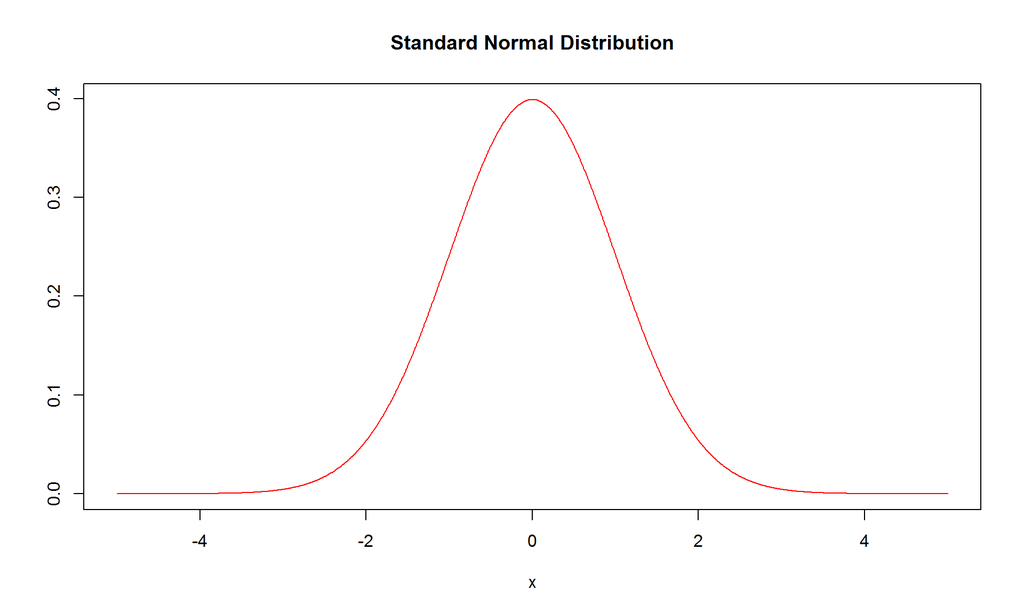

```r
x=seq(from=-5,to=5,by=0.01)
plot(x, dnorm(x), type="l", col="red", xlab="x", ylab="", main="Standard Normal Distribution")
```

## 2.5 Beta Distribution

> 베타분포의 난수 생성

```r
rbeta(10, 3, 3)
```

```
##  [1] 0.2789913 0.1705939 0.5281989 0.4328879 0.4898225 0.5775114 0.4964680
##  [8] 0.3007020 0.6277776 0.5840958
```

> 아래 그림은 베타분포의 확률밀도함수 그림이다.

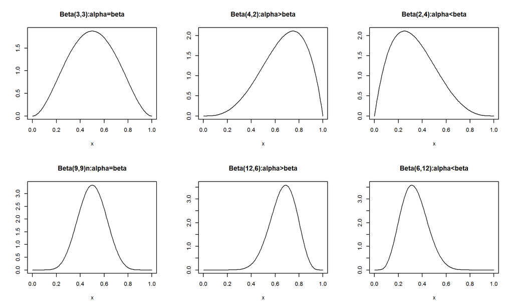

```r
x=seq(from=0,to=1,by=0.01)

par(mfrow=c(2,3))

plot(x, dbeta(x,3,3), type="l", xlab="x", ylab="", main="Beta(3,3):alpha=beta")
plot(x, dbeta(x,4,2), type="l", xlab="x", ylab="", main="Beta(4,2):alpha>beta")
plot(x, dbeta(x,2,4), type="l", xlab="x", ylab="", main="Beta(2,4):alpha<beta")

plot(x, dbeta(x,9,9), type="l", xlab="x", ylab="", main="Beta(9,9)n:alpha=beta")
plot(x, dbeta(x,12,6), type="l", xlab="x", ylab="", main="Beta(12,6):alpha>beta")
plot(x, dbeta(x,6,12), type="l", xlab="x", ylab="", main="Beta(6,12):alpha<beta")
```

> 베타분포에 신뢰구간 선 표시하기 qbeta 이용하기

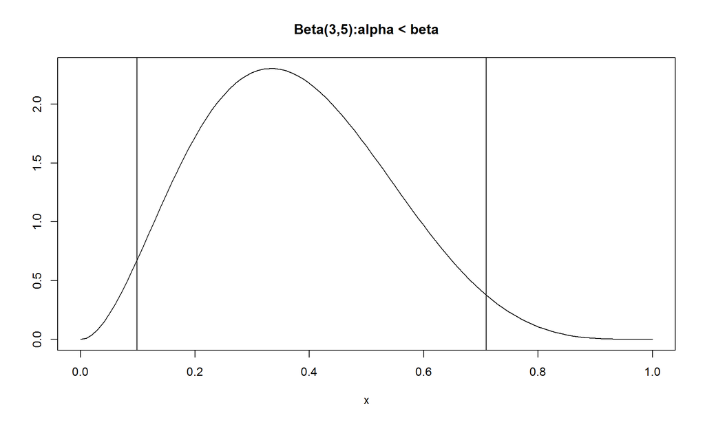

```r
par(mfrow=c(1,1))
plot(x, dbeta(x,3,5), type="l", xlab="x", ylab="", main="Beta(3,5):alpha < beta")
abline(v=qbeta(c(0.025, 0.975),3,5))
```

## 2.6 Gamma Distribution

> 감마분포의 난수생성

```r
rgamma(10, 2, 2)
```

```
##  [1] 0.2925768 1.8320501 2.1665657 0.9268011 0.5550117 0.8142929 0.6661015
##  [8] 1.2328222 0.4784363 1.6186924
```

> 아래 그림은 감마분포의 확률밀도함수 그림이다.

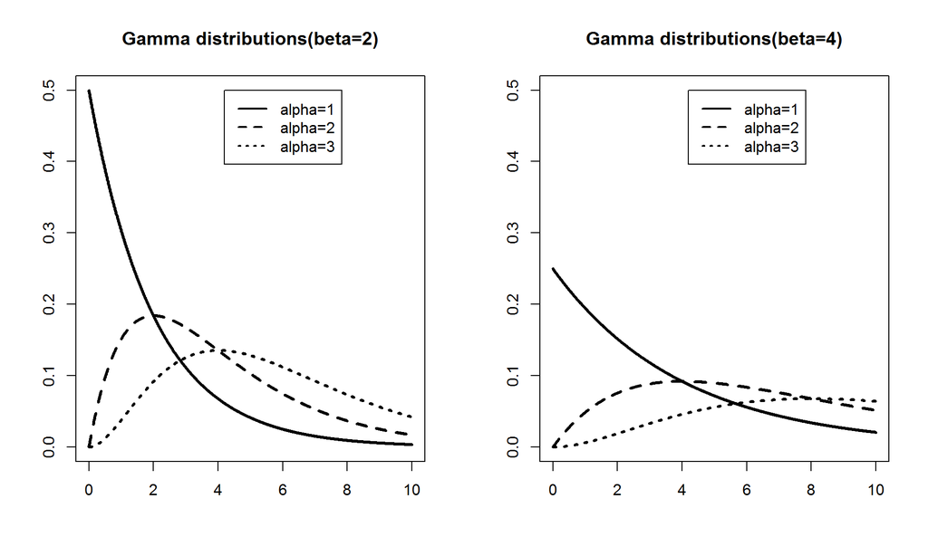

```r
x <- seq(from = 0, to = 10, by = 0.01)
par(mfrow=c(1,2))
plot(x, dgamma(x, shape=1,scale=2), type="l", lwd=3, xlab="", ylab="", main="Gamma distributions(beta=2)", ylim=c(0.0,0.5))
lines(x, dgamma(x,shape=2,scale=2), lty=2, lwd=3)
lines(x, dgamma(x,shape=3,scale=2), lty=3, lwd=3)
legend(4.2,0.5,legend=c("alpha=1","alpha=2","alpha=3"),lty=1:3,lwd=rep(2,3))

plot(x, dgamma(x,shape=1,scale=4), type="l", lwd=3, xlab="", ylab="", main="Gamma distributions(beta=4)", ylim=c(0.0,0.5))
lines(x, dgamma(x,shape=2,scale=4), lty=2, lwd=3)
lines(x, dgamma(x,shape=3,scale=4), lty=3, lwd=3)
legend(4.2,0.5,legend=c("alpha=1","alpha=2","alpha=3"),lty=1:3,lwd=rep(2,3))
```

## 2.7 t-분포 (Student’s t-distribution)

> 자유도가 커질수록 정규분포와 가까워진다.

```r
dt(0, df=3)
```

```
## [1] 0.3675526
```

```r
pt(0, df=3)
```

```
## [1] 0.5
```

```r
qt(0.5, df=3)
```

```
## [1] 0
```

```r
rt(10, df=3)
```

```
##  [1] -0.7129326  1.0520925  0.6214144 -0.8911455 -0.3603646  1.0689039
##  [7]  5.9042515 -1.5465802  1.2604398  0.5360064
```

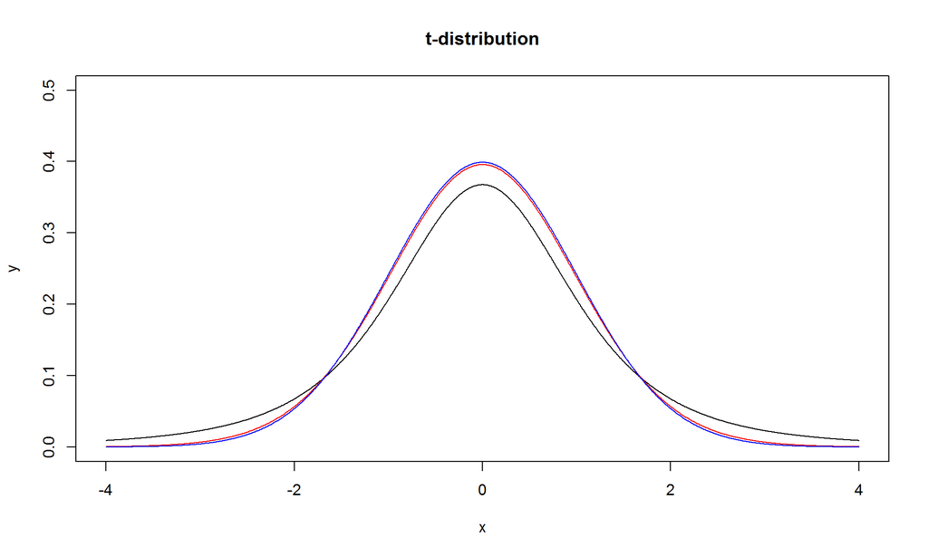

```r
x <- seq(from = -4 , to = 4 , length = 1000)
yn <- dt(x , df=3)
yn2 <- dt(x , df=30)
plot(x, yn , ylab="y", main="t-distribution",type="l", ylim=c(0, 0.5))
lines(x, yn2,col="red")
lines(x, dnorm(x,mean=0,sd=1), col="blue")
```